# Heteroscedasticidad

3/24/2021

## Naturaleza del problema

## Varianza condicional

La varianza condicional del término de error no es constante: \[E(u_i^2|x_{1i}, x_{2i}, \dots, x_{ki}) = \sigma^2_i\] y, en general, \(\sigma^2_i \neq \sigma^2_j\), cuando \(i \neq j\).

## Ejemplo 1 (I)

Simulemos una función de regresión poblacional donde la varianza del término de error crece con \(x\): \[ \begin{gather*} y = \beta_0 + \beta_1 x + u \\ u \sim N(0, \sigma^2 x^2) \end{gather*} \] Haciendo \(\beta_0 = \beta_1 = 1\) y \(\sigma^2 = 1\):

```r
N <- 500
x <- runif(N, min = 10, max = 250)
varu <-  x^2
u <- rnorm(N, sd = sqrt(varu))
y <- 1 + x + u
```

## Ejemplo 1 (II)

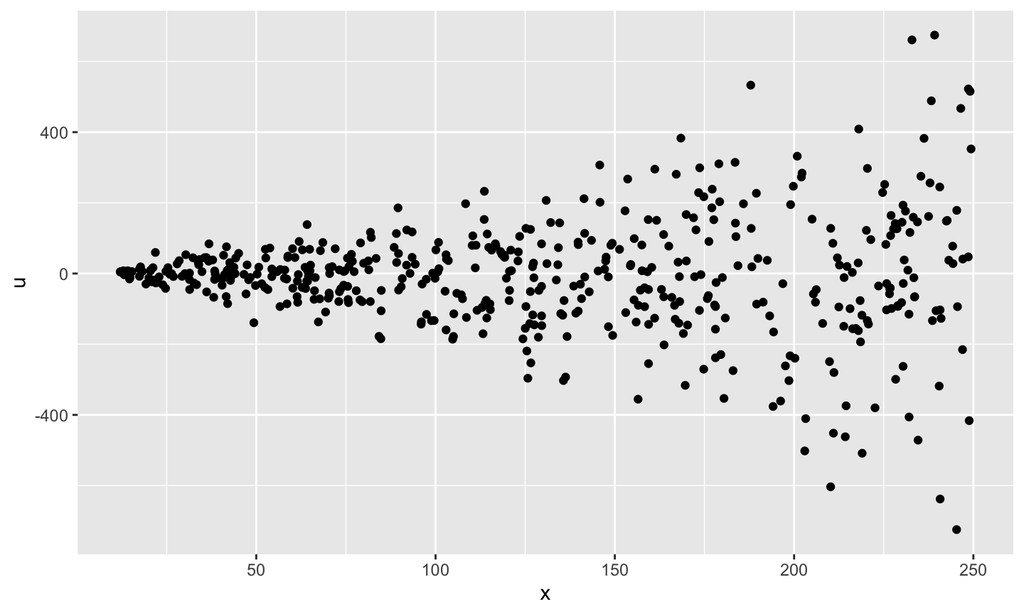

```r
library(ggplot2)
qplot(x, u)
```

## Consecuencias de la heteroscedasticidad

## Insesgadez

- La heteroscedasticidad no afecta al supuesto **RLM.4**.
- El estimador MCO sigue siendo insesgado.

## Eficiencia

- Se incumple el supuesto **RLM.5**.
- MCO no es el estimador lineal insesgado óptimo.

## Inferencia

- Las fórmulas usuales para la varianza de los estimadores MCO no son válidas bajo heteroscedasticidad.

## Ejemplo 1 (III)

Estimación MCO:

```r
mod1 <- lm(y ~ x)
summary(mod1)
```

```
##
## Call:
## lm(formula = y ~ x)
##
## Residuals:
##     Min      1Q  Median      3Q     Max
## -715.11  -72.47    4.92   69.28  684.02
##
## Coefficients:
##             Estimate Std. Error t value Pr(>|t|)
## (Intercept)  -5.3259    15.1517  -0.352    0.725
## x             0.9871     0.1032   9.562   <2e-16 ***
## ---
## Signif. codes:  0 '***' 0.001 '**' 0.01 '*' 0.05 '.' 0.1 ' ' 1
##
## Residual standard error: 161 on 498 degrees of freedom
## Multiple R-squared:  0.1551, Adjusted R-squared:  0.1534
## F-statistic: 91.42 on 1 and 498 DF,  p-value: < 2.2e-16
```

## Inferencia robusta a la heteroscedasticidad

## Errores típicos robustos

Una alternativa común es:

- Estimar los parámetros por MCO.
- Modificar el cálculo de los errores típicos de los estimadores.

## Ejemplo 1 (IV)

Utilizamos dos paquetes de R:

- `sandwich`: cáclulo de errores típicos robustos:

```r
# install.packages("sandwich")
library(sandwich)
```

- `ec1027`: datos y funciones para la asignatura:

```r
# install.packages("devtools")
# devtools::install_github("jcpernias/ec1027")
library(ec1027)
```

## Ejemplo 1 (V)

```r
coef_table(mod1, vce = vcovHC)
```

```
##
## Call:
## lm(y ~ x)
##
## Covariance matrix estimate:
## vcovHC()
##
## Coefficients:
##             Estimate Std. Error t value  Pr(>|t|)
## (Intercept) -5.32586   10.78589 -0.4938    0.6217
## x            0.98706    0.12305  8.0215 7.532e-15 ***
## ---
## Signif. codes:  0 '***' 0.001 '**' 0.01 '*' 0.05 '.' 0.1 ' ' 1
##
## Residual standard error: 161 on 498 degrees of freedom
## Multiple R-squared:  0.1551, Adjusted R-squared:  0.1534
## F-statistic: 64.34 on 1 and 498 DF,  p-value: 7.532e-15
```

## Ejemplo 1 (VI)

Comparamos los errores típicos MCO con los robustos:

```r
se_mco <- se(mod1)
se_hc <- se(mod1, vcovHC)
cmp <- cbind(MCO = se_mco, HC = se_hc, "MCO / HC" = se_mco / se_hc)
round(cmp, 3)
```

```
##                MCO     HC MCO / HC
## (Intercept) 15.152 10.786    1.405
## x            0.103  0.123    0.839
```

## Contrastes de heteroscedasticidad

## ¿Por qué?

- ¿Es necesario usar errores típicos robustos?
- ¿Es necesario usar estimadores más eficientes que MCO?

## Contraste de White (I)

Halbert White muestra que hay problemas con MCO cuando la varianza condicional depende de:

- Las variables explicativas: \(x_1, x_2, \dots, x_k\).
- Los cuadrados de las variables explicativas: \(x^2_1, x^2_2, \dots, x^2_k\).
- Los productos cruzados: \(x_1 \cdot x_2, x_1 \cdot x_3, \dots\)

## Contraste de White (II)

Para contrastar la hipótesis nula se puede usar:

- El estadístico LM: \(N R^2\).
- El estadístico \(F\) para contrastar la significación conjunta de la regresión auxiliar.

## Ejemplo 2 (I)

Modelo de determinación de los precios de venta de las casas: \[ price = \beta_0 + \beta_1 sqrft + \beta_2 lotsize + \beta_3 bdrms + u \]

## Ejemplo 2 (II)

Estimación por MCO:

```r
mod2 <- lm(price ~ sqrft + lotsize + bdrms, data = hprice1)
coef_table(mod2)
```

```
##
## Call:
## lm(price ~ sqrft + lotsize + bdrms, data = hprice1)
##
## Coefficients:
##                Estimate  Std. Error t value  Pr(>|t|)
## (Intercept) -2.1770e+01  2.9475e+01 -0.7386  0.462208
## sqrft        1.2278e-01  1.3237e-02  9.2751 1.658e-14 ***
## lotsize      2.0677e-03  6.4213e-04  3.2201  0.001823 **
## bdrms        1.3853e+01  9.0101e+00  1.5374  0.127945
## ---
## Signif. codes:  0 '***' 0.001 '**' 0.01 '*' 0.05 '.' 0.1 ' ' 1
##
## Residual standard error: 59.83 on 84 degrees of freedom
## Multiple R-squared:  0.6724, Adjusted R-squared:  0.6607
## F-statistic: 57.46 on 3 and 84 DF,  p-value: < 2.2e-16
```

## Ejemplo 2 (III)

Versión F del contraste de White:

```r
white_test(mod2)
```

```
##
##  White's test for heteroskedasticity
##
## data:  Auxiliary regression of squared residuals from:
##   lm(price ~ sqrft + lotsize + bdrms, data = hprice1)
## on all covariates, their squares and cross-products.
##
##
## F = 5.387, df1 = 9, df2 = 78, p-value = 1.013e-05
```

## Ejemplo 2 (IV)

Versión LM del contraste de White:

```r
white_test(mod2, chisq = TRUE)
```

```
##
##  White's test for heteroskedasticity
##
## data:  Auxiliary regression of squared residuals from:
##   lm(price ~ sqrft + lotsize + bdrms, data = hprice1)
## on all covariates, their squares and cross-products.
##
##
## X-squared = 33.732, df = 9, p-value = 9.953e-05
```

## Contraste de White (III)

En la regresión auxiliar del contraste de White hay un gran número de parámetros. Esto puede provocar que el contraste de White tenga poca **potencia** (capacidad de detectar heteroscedasticidad cuando realmente está presente).

## Contraste de White (IV)

Para mitigar ese problema, en ocasiones se omiten los productos cruzados en la regresión auxiliar.

## Ejemplo 2 (V)

Versión F del contraste de White, sin incluir productos cruzados:

```r
white_test(mod2, full = FALSE)
```

```
##
##  White's test for heteroskedasticity
##
## data:  Auxiliary regression of squared residuals from:
##   lm(price ~ sqrft + lotsize + bdrms, data = hprice1)
## on all covariates and their squares.
##
##
## F = 4.1267, df1 = 6, df2 = 81, p-value = 0.001151
```

## Otros contrastes

La heteroscedasticidad puede contrastarse mediante una regresión auxiliar de los residuos MCO al cuadrado sobre un conjunto de variables que estén relacionadas con la varianza del término de error. Puede usarse:

- El estadítico LM.
- El contraste \(F\) de significación conjunta.

## Ejemplo 2 (VI)

Versión F de un contraste de heteroscedasticidad usando todas las explicativas:

```r
het_test(mod2)
```

```
##
##  LM test for heteroskedasticity
##
## data:  Auxiliary regression of squared residuals from:
##   lm(price ~ sqrft + lotsize + bdrms, data = hprice1)
## on all covariates.
##
##
## F = 5.3389, df1 = 3, df2 = 84, p-value = 0.002048
```

## Ejemplo 2 (VII)

Versión F de un contraste de heteroscdasticidad usando `sqrft` y `lotsize`:

```r
het_test(mod2, ~ sqrft + lotsize)
```

```
##
##  LM test for heteroskedasticity
##
## data:  Auxiliary regression of squared residuals from:
##   lm(price ~ sqrft + lotsize + bdrms, data = hprice1)
## on: ~sqrft + lotsize.
##
##
## F = 7.4536, df1 = 2, df2 = 85, p-value = 0.001041
```

## Ejemplo 2 (VIII)

Wooldridge propone usar las prediciones MCO en niveles y al cuadrado:

```r
yhat2 <- fitted(mod2)
sq_yhat2 <- yhat2^2
het_test(mod2, ~ yhat2 + sq_yhat2)
```

```
##
##  LM test for heteroskedasticity
##
## data:  Auxiliary regression of squared residuals from:
##   lm(price ~ sqrft + lotsize + bdrms, data = hprice1)
## on: ~yhat2 + sq_yhat2.
##
##
## F = 9.6388, df1 = 2, df2 = 85, p-value = 0.0001687
```

## Estimación eficiente

## Mínimos cuadrados generalizados (MCG)

La idea detrás de MCG es:

1. Transformar el modelo de forma que se cumplan los supuestos de Gauss-Markov.
2. Aplicar MCO al modelo transformado.

## Mínimos cuadrados ponderados (I)

- Función de regresión poblacional: \[ y_i = \beta_0 + \beta_1 x_{1i} + \beta_2 x_{2i} + u_i \]
- Consideremos el caso en que: \[ V(u_i | x_{1i}, x_{2i}) = E(u_i^2 | x_{1i}, x_{2i}) = \sigma^2 x^2_{2i} \]

## Mínimos cuadrados ponderados (II)

- Transformación del modelo: dividimos por \(x_{2i}\): \[ \frac{y_i}{x_{2i}} = \beta_0 \frac{1}{x_{2i}}+ \beta_1 \frac{x_{1i}}{x_{2i}} + \beta_2 \frac{x_{2i}}{x_{2i}} + \frac{u_i}{x_{2i}} \]
- Reescribimos el modelo como: \[ y^*_i = \beta_2 + \beta_0 x^*_{0i} + \beta_1 x^*_{1i} + u^*_i \] donde \(y^*_i = y_i / x_{2i}\), \(x^*_{0i} = 1 / x_{2i}\), \(x^*_{1i} = x_{1i} / x_{2i}\), \(u^*_i = u_i / x_{2i}\).

## Mínimos cuadrados ponderados (II)

- El término de error del modelo transformado es homoscedástico: \[ \begin{align*} E(u^*_i{}^2| x_{1i}, x_{2i}) &= E((u_i/x_{2i})^2|x_{1i}, x_{2i}) \\ &= (1/x_{2i})^2E(u_i^2| x_{1i}, x_{2i}) \\ &= (1/x^2_{2i}) \sigma^2 x_{2i}^2 \\ &= \sigma^2 \end{align*} \]
- El estimador ELIO consiste en aplicar MCO al modelo transformado.

## Mínimos cuadrados ponderados (III)

Resumen:

- La varianza del término de error es proporcional a \(h_i\) que es una función conocida de variables observables: \[ V(u_i | x_{1i}, x_{2i}, \dots, x_{ki}) = \sigma^2 h_{i} \]
- Transformamos el modelo dividiendo todas las variables (y el término constante) por \(\sqrt{h_i}\).
- Estimamos el modelo transformado por MCO.

## Ejemplo 2 (IX)

Volvemos a nuestro modelo de determinación de los precios de venta de las casas: \[ price = \beta_0 + \beta_1 sqrft + \beta_2 lotsize + \beta_3 bdrms + u \] Supongamos que la varianza condicional de \(u_i\) es proporcional al cuadrado de la variable \(lotsize\): \[ E(u^2_i | sqrft_i, lotsize_i, bdrms_i) = \sigma^2 lotsize_i^2 \] por lo que, en este caso \(h_i = lotsize_i^2\).

## Ejemplo 2 (X)

En `R` para obtener el estimador MCP utilizamos la opción `weights` de la función `lm`. Indicamos la inversa de la función de dispersión \(h_i\).

```r
hprice1$h <- hprice1$lotsize^2
mcp <- lm(price ~ sqrft + lotsize + bdrms, data = hprice1, weights = 1 / h)
coef_table(mcp)
```

```
##
## Call:
## lm(price ~ sqrft + lotsize + bdrms, data = hprice1, weights = 1/h)
##
## Coefficients:
##               Estimate Std. Error t value  Pr(>|t|)
## (Intercept) 21.9045767 30.4159527  0.7202    0.4734
## sqrft        0.0972915  0.0089171 10.9107 < 2.2e-16 ***
## lotsize      0.0073581  0.0017215  4.2741  5.04e-05 ***
## bdrms        3.8371278  7.0429284  0.5448    0.5873
## ---
## Signif. codes:  0 '***' 0.001 '**' 0.01 '*' 0.05 '.' 0.1 ' ' 1
##
## Residual standard error: 0.007588 on 84 degrees of freedom
## Multiple R-squared:  0.5919, Adjusted R-squared:  0.5773
## F-statistic:  40.6 on 3 and 84 DF,  p-value: 2.581e-16
```

## MCP factibles (I)

- Hasta ahora hemos supuesto que conocemos \(h_i\).
- ¿Qué podemos hacer si no observamos \(h_i\)?

## MCP factibles (II)

- Función de regresión poblacional: \[ y_i = \beta_0 + \beta_1 x_{1i} + \beta_2 x_{2i} + u_i \]
- Consideremos ahora el caso en que: \[ E(u_i^2 | x_{1i}, x_{2i}) = \sigma^2 \exp(\delta_0 + \delta_1 x_{2i} + \delta_2 x^2_{2i}) \] La función de dispersión depende de parámetros desconocidos: \[ h_i =\exp(\delta_0 + \delta_1 x_{2i} + \delta_2 x^2_{2i}) \]

## MCP factibles (III)

- Para aplicar el principio de MCG primero debemos estimar los parámetros de los que depende \(h_i\) y obtener una estimación de la función de dispersión, \(\hat{h}_i\).
- Transformamos el modelo dividiendo por \(\sqrt{\hat{h}_i}\).
- Aplicamos MCO al modelo transformado.

## Estimación de \(h_i\) (I)

- Varianza condicional: \[ E(u_i^2 | x_{1i}, x_{2i}) = \sigma^2 \exp(\delta_0 + \delta_1 x_{2i} + \delta_2 x^2_{2i}) \]
- A partir de la ecuación anterior, podemos escribir: \[ u_i^2 = \sigma^2 \exp(\delta_0 + \delta_1 x_{2i} + \delta_2 x^2_{2i}) v_i \]
- Tomando logaritmos: \[ \log(u_i^2) = \theta_0 + \delta_1 x_{2i} + \delta_2 x^2_{2i} + e_i \]

## Estimación de \(h_i\) (II)

- Estimamos los parámetros de: \[ \log(u_i^2) = \theta_0 + \delta_1 x_{2i} + \delta_2 x^2_{2i} + e_i \] reemplazando \(u_i\) por los residuos de mínimos cuadrados, \(\hat{u}_i\)
- Finalmente obtenemos \(\hat{h}_i\) tomando la exponencial de los valores predichos en la regresión anterior.

## Ejemplo 2 (XII)

- Estimamos por MCO y guardamos los residuos:

```r
mod2 <- lm(price ~ sqrft + lotsize + bdrms, data = hprice1)
uhat2 <- resid(mod2)
```

- Calculamos el logaritmo de los cuadrados de los residuos, el cuadrado de \(lotsize\) y estimamos la regresión auxiliar:

```r
lsq_uhat2 <- log(uhat2^2)
sq_lotsize <- hprice1$lotsize^2
aux <- lm(lsq_uhat2 ~ lotsize + sq_lotsize, data = hprice1)
```

- Calculamos la estimación de \(h_i\):

```r
hhat <- exp(fitted(aux))
```

## Ejemplo 2 (XII)

- Finalmente, utilizamos \(\hat{h}_i\) para transformar el modelo. El estimador de MCP factibles sería:

```r
mcpf <- lm(price ~ sqrft + lotsize + bdrms, data = hprice1, weights = 1 / hhat)
coef_table(mcpf)
```

```
##
## Call:
## lm(price ~ sqrft + lotsize + bdrms, data = hprice1, weights = 1/hhat)
##
## Coefficients:
##               Estimate Std. Error t value  Pr(>|t|)
## (Intercept)  5.9550772 27.2697587  0.2184   0.82767
## sqrft        0.0921532  0.0126909  7.2614 1.784e-10 ***
## lotsize      0.0063796  0.0015340  4.1589 7.678e-05 ***
## bdrms       13.3167944  7.7144813  1.7262   0.08799 .
## ---
## Signif. codes:  0 '***' 0.001 '**' 0.01 '*' 0.05 '.' 0.1 ' ' 1
##
## Residual standard error: 1.922 on 84 degrees of freedom
## Multiple R-squared:  0.6293, Adjusted R-squared:  0.616
## F-statistic: 47.52 on 3 and 84 DF,  p-value: < 2.2e-16
```

## Comparación con MCO

- MCP y MCO son insesgados bajo heteroscedasticidad. No debería haber una gran diferencia entre ambas estimaciones.
- No son comparables los coeficientes de determinación y el error típico de la regresión de MCO y MCP.
- Igual que con MCO, es posible usar matrices de covarianzas robustas después de estimar por MCP.

## Alternativas a MCP

- La heteroscedasticidad suele estar asociada con el “tamaño” de las observaciones.
- Con frecuencia, los problemas de heteroscedasticidad pueden mitigarse usando logaritmos.

## Ejemplo 2 (XIII)

Modelo de determinación de los precios de venta de las casas: \[ \log(price) = \beta_0 + \beta_1 \log(sqrft) + \beta_2 \log(lotsize) + \beta_3 bdrms + u \] Transformamos las variables:

```r
hprice1 <- within(hprice1, {
  lprice <- log(price)
  lsqrft <- log(sqrft)
  llotsize <- log(lotsize)
})
```

## Ejemplo 2 (XIV)

Estimación por MCO:

```r
mod3 <- lm(lprice ~ lsqrft + llotsize + bdrms, data = hprice1)
coef_table(mod3)
```

```
##
## Call:
## lm(lprice ~ lsqrft + llotsize + bdrms, data = hprice1)
##
## Coefficients:
##              Estimate Std. Error t value  Pr(>|t|)
## (Intercept) -1.297042   0.651284 -1.9915   0.04967 *
## lsqrft       0.700232   0.092865  7.5403 5.006e-11 ***
## llotsize     0.167967   0.038281  4.3877 3.307e-05 ***
## bdrms        0.036958   0.027531  1.3424   0.18308
## ---
## Signif. codes:  0 '***' 0.001 '**' 0.01 '*' 0.05 '.' 0.1 ' ' 1
##
## Residual standard error: 0.1846 on 84 degrees of freedom
## Multiple R-squared:  0.643,  Adjusted R-squared:  0.6302
## F-statistic: 50.42 on 3 and 84 DF,  p-value: < 2.2e-16
```

## Ejemplo 2 (XV)

Contraste de White:

```r
white_test(mod3)
```

```
##
##  White's test for heteroskedasticity
##
## data:  Auxiliary regression of squared residuals from:
##   lm(lprice ~ lsqrft + llotsize + bdrms, data = hprice1)
## on all covariates, their squares and cross-products.
##
##
## F = 1.055, df1 = 9, df2 = 78, p-value = 0.4053
```